# Introduction

This project analyses historical stock price data for UK-listed companies to assess the validity of Geometric Brownian Motion to model the prices. The analysis begins by importing and cleaning the data set and selecting an appropriate historical time period. Daily logarithmic returns are then calculated for each stock, and key statistical parameters are estimated from the resulting data.

The analysis initially focuses on an individual stock, examining its historical price movements, return distribution and volatility statistics. Simulated price paths are subsequently generated and compared with observed prices, with forecast accuracy assessed across different historical estimation windows. Statistical diagnostic tests are also conducted to investigate the distribution of returns, their dependence over time and potential clustering in volatility.

The analysis is then extended across multiple stocks and industries. Simulation performance is compared using percentage errors, root mean squared errors and prediction interval coverage. Statistics per industry are assessed using skewness and excess kurtosis. The results are summarised in tables and graphical comparisons to identify differences between industries and consistent patterns across the entire data set.

### Setup

General possible reasons to exclude a ticker from the list are: (need to review these, just provisional at the moment)

1. Assigned to a list
2. Missing Columns
3. Invalid Dates / Prices
4. Outside date range selected
5. <30 usable prices
6. <20 finite log returns
7. s.d of log returns is 0 or infinite
8. Chosen to run 500 paths per stock (can be changed)

### Sources

1. Cont 2001: Empirical Properties of asset returns: stylized facts and statistical issues
2. Fama, E. F. (1965). The Behaviour of Stock-Market Prices

```r
folder <- "C:/Users/lucas/OneDrive/ALL PC STUFF/Desktop/GBM Data"
files <- list.files(
  path = folder,
  pattern = "\\.csv$",
  full.names = TRUE
)


data_list <- lapply(files, read.csv)


names(data_list) <- tools::file_path_sans_ext(basename(files))

# Display all available stock tickers
names(data_list)
```

```
##   [1] "AAF"  "AAL"  "ABDN" "ABF"  "ADM"  "ALW"  "ANTO" "AUTO" "AV"   "AZN"
##  [11] "BA"   "BAB"  "BARC" "BATS" "BBOX" "BBY"  "BGEO" "BLND" "BNZL" "BP"
##  [21] "BRBY" "BT.A" "BTRW" "CCC"  "CCEP" "CNA"  "CPG"  "CRDA" "CTEC" "DGE"
##  [31] "DPLM" "EDV"  "EXPN" "EZJ"  "FCIT" "FRAS" "FRES" "GAW"  "GSK"  "HBR"
##  [41] "HLMA" "HLN"  "HSBA" "HWDN" "ICG"  "IHG"  "III"  "IMB"  "IMI"  "INF"
##  [51] "INVP" "ITH"  "ITRK" "JD"   "KGF"  "LAND" "LGEN" "LLOY" "LMP"  "LSEG"
##  [61] "MKS"  "MNG"  "MRO"  "MTLN" "NG"   "NWG"  "NXT"  "PCT"  "PRU"  "PSN"
##  [71] "PSON" "REL"  "RIO"  "RKT"  "RMV"  "ROR"  "RR"   "RSW"  "RTO"  "SBRY"
##  [81] "SCT"  "SDLF" "SGE"  "SGRO" "SHEL" "SMIN" "SMT"  "SN"   "SPX"  "SSE"
##  [91] "STAN" "STJ"  "SVT"  "TSCO" "ULVR" "UU"   "VOD"  "WEIR" "WTB"  "ZEG"
```

## Setup for Individual Stocks

Select Stock from Ticker, Start and End Date, extract Price data from source and perform checks for validity of data

#### Checks

1. identify if start and end dates are missing and start date > end date
2. check stock is in data list
3. check close column exists in data
4. check date field can be converted to a date
5. filter data for dates between start and end
6. sort by date ascending

```r
# Choose initial stock
Chosen_Stock <- "BP"

# Choose start and end dates
start_date <- as.Date("2020-01-01")
end_date   <- as.Date("2022-12-31")

# Various tests for validity of date ranges, fields, formats and completeness
if (is.na(start_date) || is.na(end_date) || start_date > end_date) {
  stop("Invalid date range: check that start_date is before or equal to end_date.")
}

if (!Chosen_Stock %in% names(data_list)) {
  stop(paste0(
    "Stock '", Chosen_Stock,
    "' was not found in data_list. Check the ticker name."
  ))
}

# Load selected stock
stock <- data_list[[Chosen_Stock]]

if (!"close" %in% names(stock)) {
  stop(paste0(
    "Stock '", Chosen_Stock,
    "' does not contain a close column."
  ))
}

if (!"date" %in% names(stock)) {
  stop(paste0(
    "Stock '", Chosen_Stock,
    "' does not contain a 'date' column. Check the actual column name."
  ))
}

# Convert dates and extract closing prices
all_dates <- as.Date(stock$date, format = "%Y-%m-%d")
all_prices <- stock$close

if (all(is.na(all_dates))) {
  stop("Date conversion failed. Check the date format in stock$date.")
}

# Select valid data within the requested date range
selected <- !is.na(all_dates) &
  all_dates >= start_date &
  all_dates <= end_date &
  is.finite(all_prices) &
  all_prices > 0
# All Prices > 0 is a constraint of the model

# Stop if no valid prices exist in the selected period
if (!any(selected)) {
  stop(paste0(
    "No valid closing-price data for ", Chosen_Stock,
    " between ", format(start_date, "%Y-%m-%d"),
    " and ", format(end_date, "%Y-%m-%d"),
    ". Check the date range and date format."
  ))
}

# Keep only selected dates and prices
dates <- all_dates[selected]
prices <- all_prices[selected]

# Sort observations by date
ordering <- order(dates)
dates <- dates[ordering]
prices <- prices[ordering]

# Check sufficient data for returns and simulation
if (length(prices) < 2) {
  stop("Fewer than two valid prices are available. At least two are required.")
}

# Report successful selection
cat("Stock:", Chosen_Stock, "\n")
```

```
## Stock: BP
```

```r
cat("Start date Chosen:", format(min(dates), "%Y-%m-%d"), "\n")
```

```
## Start date Chosen: 2020-01-02
```

```r
cat("End date Chosen:", format(max(dates), "%Y-%m-%d"), "\n")
```

```
## End date Chosen: 2022-12-30
```

```r
cat("Number of prices:", length(prices), "\n")
```

```
## Number of prices: 757
```

#### Log Returns

$$r_{n+1} = \log(S_{n+1}) - \log(S_n)$$

Daily Log Returns calculated across entire time period. Approximate number of years calculated from number of prices / 252 (business days py)

```r
#difference between the log of the prices on a daily basis
log_returns <- diff(log(prices))

#approximate time period in years is calculated based on the number of prices / 252 trading days py
n <- length(log_returns)
trading_days <- 252
# 252 Business Days py
T <- n / trading_days

time <- seq(0, T, length.out = n + 1)

cat("Number of daily returns:", n, "\n")
```

```
## Number of daily returns: 756
```

```r
cat("Approximate time period (years):", round(T, 2), "\n")
```

```
## Approximate time period (years): 3
```

#### Geometric Brownian Motion Equation

$$S_t = S_0 \exp\left(\left(\mu - \frac{\sigma^2}{2}\right)t + \sigma
W_t\right)$$

Estimate Annual Drift and Velocity

$$\hat{\sigma}=s_r\sqrt{252}$$

where the daily log-return standard deviation is

$$s_r=\sqrt{\frac{1}{n-1}\sum_{t=1}^{n}(r_t-\bar r)^2}$$

- $S_t$ is the stock price at time $t$.
- $r_t$ is the daily log return.
- $\bar r=\frac{1}{n}\sum_{t=1}^{n}r_t$ is the mean daily log return.
- $n$ is the number of daily log returns.
- $252$ is the number of trading days per year.

#### Annualised Drift

$$\hat{\mu}=252\bar r+\frac{1}{2}\hat{\sigma}^{\,2}$$

Substituting the volatility estimate gives

$$\hat{\mu}=252\bar r+\frac{1}{2}(252s_r^2)$$

Equivalently,

$$\hat{\mu}=252\left(\bar r+\frac{1}{2}s_r^2\right)$$

where $\hat{\mu}$ is the estimated annualised GBM drift parameter.

The additional term $\frac12\hat{\sigma}^2$ arises from the GBM model:

It adjusts the annualised mean log return to estimate the drift parameter $\mu$.

```r
sigma_hat <- sd(log_returns) * sqrt(trading_days)

mu_hat <- mean(log_returns) * trading_days +
  0.5 * sigma_hat^2

cat("Annualised drift:", round(mu_hat, 4), "\n")
```

```
## Annualised drift: 0.0894
```

```r
cat("Annualised volatility:", round(sigma_hat, 4), "\n")
```

```
## Annualised volatility: 0.431
```

## Simulate 500 GBM Paths

maybe an idea to look at simulating over an increasing number of paths but run into computational issues

```r
# Simulate 100 independent GBM paths
set.seed(123)

n_simulations <- 500

# Number of daily intervals
n <- length(prices) - 1

# Time in years
time <- (0:n) / trading_days

# Starting share price
S0 <- prices[1]

# Generate independent daily log-price increments
daily_increments <- matrix(
  rnorm(
    n * n_simulations,
    mean = (mu_hat - 0.5 * sigma_hat^2) / trading_days,
    sd = sigma_hat / sqrt(trading_days)
  ),
  nrow = n,
  ncol = n_simulations
)

# Construct all 100 simulated price paths
simulated_prices <- rbind(
  rep(S0, n_simulations),
  S0 * exp(apply(daily_increments, 2, cumsum))
)

# Check dimensions
dim(simulated_prices)
```

```
## [1] 757 500
```

### Historical Prices against simulated prices

[figure not shown]

```r
# Plot 100 simulated paths against actual historical prices

matplot(
  dates,
  simulated_prices,
  type = "l",
  lty = 1,
  col = adjustcolor("blue", alpha.f = 0.35),
  xlab = "Date",
  ylab = "Share price",
  main = paste(
    Chosen_Stock,
    ": Historical Prices vs 100 GBM Simulations"
  ),
  xaxt = "n"
)

# Add date labels
date_ticks <- pretty(dates, n = 6)
axis.Date(1, at = date_ticks, format = "%Y-%m")

# Add historical share price
lines(
  dates,
  prices,
  col = "red",
  lwd = 2
)

# Add legend
legend(
  "topleft",
  legend = c(
    "100 simulated GBM paths",
    "Actual historical price"
  ),
  col = c("blue", "red"),
  lty = 1,
  lwd = c(1, 2),
  bty = "n",
  cex = 0.85
)
```

Each blue line is a random walk using the estimated parameters and red line is the actual price

## Summary Statistics of log returns

```r
summary(log_returns)
```

```
##       Min.    1st Qu.     Median       Mean    3rd Qu.       Max.
## -2.168e-01 -1.413e-02  2.099e-04 -1.384e-05  1.393e-02  1.954e-01
```

```r
cat("Daily volatility:", sd(log_returns), "\n")
```

```
## Daily volatility: 0.02715169
```

```r
cat("Annualised volatility:", sigma_hat, "\n")
```

```
## Annualised volatility: 0.4310197
```

### Are log(returns) normally distributed?

log return could be adapted do a Jarque - Bera Test

used in cont and Fama Sources

Closer aligned to red line closer fit to normal distribution

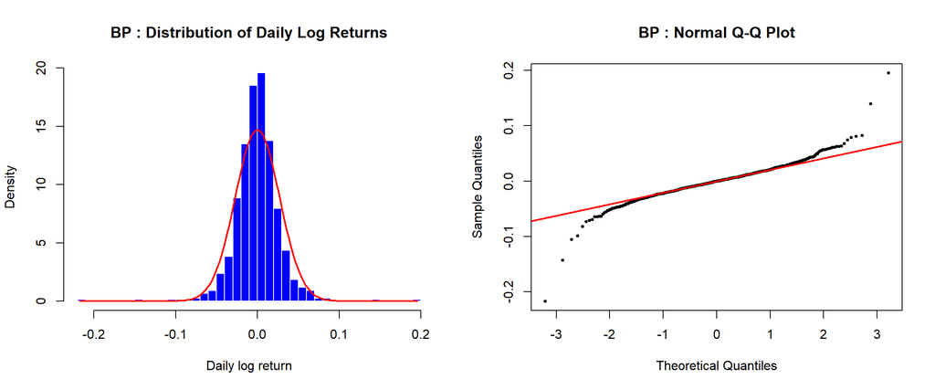

```r
old_par <- par(no.readonly = TRUE)

par(mfrow = c(1, 2))

# Distribution of actual daily log returns
hist(
  log_returns,
  breaks = 50,
  probability = TRUE,
  main = paste(Chosen_Stock, ": Distribution of Daily Log Returns"),
  xlab = "Daily log return",
  ylab = "Density",
  col = "blue",
  border = "white"
)

# Overlay normal distribution
x <- seq(
  min(log_returns, na.rm = TRUE),
  max(log_returns, na.rm = TRUE),
  length.out = 200
)

lines(
  x,
  dnorm(x, mean = mean(log_returns, na.rm = TRUE),
        sd = sd(log_returns, na.rm = TRUE)),
  col = "red",
  lwd = 2
)

# Normal Q-Q plot
qqnorm(
  log_returns,
  main = paste(Chosen_Stock, ": Normal Q-Q Plot"),
  pch = 19,
  cex = 0.5
)

qqline(log_returns, col = "red", lwd = 2)
```

```r
par(old_par)
```

### Check for Volatility Clustering

#### Autocorrelation of Squared Returns

Checks if there are periods of consistent high returns or low returns - essentially checking if there is a correlation between the absolute value of the returns across different time periods. Spikes in the ACF that extend past the confidence band (dashed blue line) show that there is some correlation.

This exact graph is not used in any sources so can be removed.

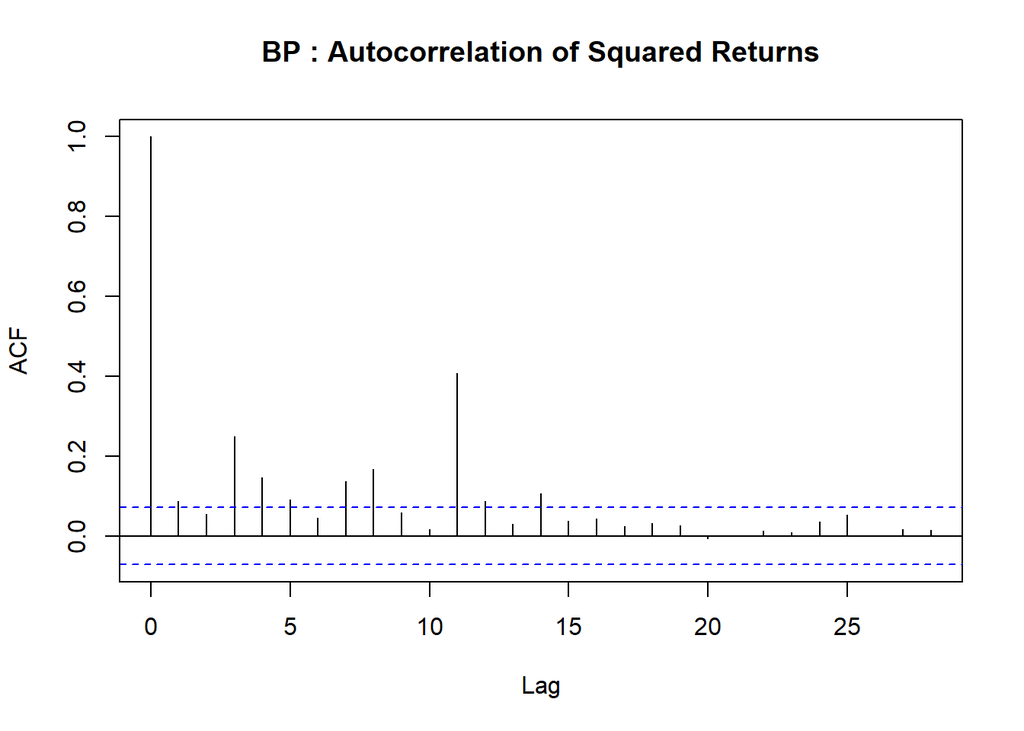

```r
acf(
  log_returns^2,
  main = paste(Chosen_Stock, ": Autocorrelation of Squared Returns"))
```

#### ARCH Test

```r
library(FinTS)
ArchTest(log_returns, lags = 10)
```

```
##
##  ARCH LM-test; Null hypothesis: no ARCH effects
##
## data:  log_returns
## Chi-squared = 78.227, df = 10, p-value = 1.117e-12
```

Autoregressive Conditional Hetero Skedasticity test used to determine if a time series exhibits volatility cluttering. Smaller probability is high probability of an ARCH effect. Essentially hypothesis test of autocorrelation graph above.

Test checks if the current squared returns are correlated to the 10 previous days (from lags = 10).

used in cont source

## Different Time Periods (unfinished)

```r
# Select stock
prices <- data_list[[Chosen_Stock]]$close
prices <- prices[is.finite(prices) & prices > 0]

# Historical estimation windows, measured in trading days
windows <- c(
  "1 month" = 21,
  "3 months" = 63,
  "6 months" = 126,
  "1 year" = 252,
  "2 years" = 504
)

# Forecast horizon: approximately one month
forecast_days <- 21
trading_days <- 252
```

For Different Periods

```r
compare_window <- function(prices, window, forecast_days = 21,
                           trading_days = 252) {

  # Error Handling
  if (length(prices) < window + forecast_days) {
    return(data.frame(
      Mean_APE = NA_real_,
      Median_APE = NA_real_,
      Mean_Annual_Volatility = NA_real_,
      Forecasts = 0
    ))
  }

  errors <- numeric(0)
  volatility_estimates <- numeric(0)

  # Rolling forecasts
  starts <- seq(
    from = window + 1,
    to = length(prices) - forecast_days + 1,
    by = forecast_days
  )

  for (i in starts) {

    estimation_prices <- prices[(i - window):(i - 1)]
    returns <- diff(log(estimation_prices))

    sigma_hat <- sd(returns) * sqrt(trading_days)
    mu_hat <- mean(returns) * trading_days +
      0.5 * sigma_hat^2

    S0 <- prices[i - 1]

    # Expected price after the forecast period
    predicted_price <- S0 * exp(
      mu_hat * forecast_days / trading_days
    )

    actual_price <- prices[i + forecast_days - 1]

    error <- abs(predicted_price - actual_price) /
      actual_price * 100

    errors <- c(errors, error)
    volatility_estimates <- c(volatility_estimates, sigma_hat)
  }

  data.frame(
    Mean_APE = mean(errors),
    Median_APE = median(errors),
    Mean_Annual_Volatility = mean(volatility_estimates),
    Forecasts = length(errors)
  )
}

# Compare each estimation window
comparison_list <- lapply(windows, function(w) {
  compare_window(prices, w, forecast_days, trading_days)
})

comparison <- do.call(rbind, comparison_list)
comparison$Period <- names(windows)
rownames(comparison) <- NULL

comparison <- comparison[, c(
  "Period", "Mean_APE", "Median_APE",
  "Mean_Annual_Volatility", "Forecasts"
)]

knitr::kable(comparison, digits = 3)
```

| Period | Mean_APE | Median_APE | Mean_Annual_Volatility | Forecasts |
| --- | --- | --- | --- | --- |
| 1 month | 11.110 | 7.682 | 0.522 | 493 |
| 3 months | 8.130 | 5.224 | 0.607 | 491 |
| 6 months | 7.557 | 4.763 | 0.632 | 488 |
| 1 year | 7.151 | 4.595 | 0.649 | 482 |
| 2 years | 7.031 | 4.770 | 0.670 | 470 |

## Comparison of Different Sectors

The different sectors have been defined by a classification based on each companies main activities

in the future could use the ftse classification but this could be too granular to properly sort the companies into big enough categories

```r
industry_tickers <- list(

  "Energy and Utilities" = c(
    "BP", "CNA", "HBR", "ITH", "NG", "SHEL", "SSE", "SVT", "UU"
  ),

  "Mining and Metals" = c(
    "AAL", "ANTO", "EDV", "FRES", "MLTN", "RIO"
  ),

  "Financials" = c(
    "ABDN", "ADM", "AV", "BARC", "BGEO", "HSBA", "ICG", "III",
    "INVP", "LGEN", "LLOY", "MNG", "NWG", "PRU", "SDLF",
    "STAN", "STJ", "LSEG", "EXPN"
  ),

  "Industrials and Engineering" = c(
    "BA", "BAB", "BBY", "BNZL", "CRDA", "DPLM", "HLMA",
    "IMI", "ITRK", "MRO", "ROR", "RSW", "SMIN", "SPX", "WEIR"
  ),

  "Consumer Staples" = c(
    "ABF", "BATS", "CCEP", "DGE", "IMB", "RKT",
    "SBRY", "TSCO", "ULVR"
  ),

  "Consumer Discretionary and Retail" = c(
    "BRBY", "FRAS", "GAW", "JD", "KGF", "MKS", "NXT"
  ),

  "Travel, Leisure and Hospitality" = c(
    "CPG", "EZJ", "IHG", "WTB"
  ),

  "Healthcare" = c(
    "AZN", "CTEC", "GSK", "HLN", "SN"
  ),

  "Technology, Media and Telecoms" = c(
    "AAF", "AUTO", "BT.A", "CCC", "INF", "PSON",
    "REL", "SCT", "SGE", "VOD", "ZEG"
  ),

  "Property and Housebuilding" = c(
    "BBOX", "BLND", "BTRW", "LAND", "LMP", "PSN", "SGRO"
  ),

  "Business Services and Building Products" = c(
    "HWDN", "RTO", "RMV"
  ),

  "Investment Trusts" = c(
    "ALW", "FCIT", "PCT", "SMT"
  )
)
```

calculate parameters for every stock in the same way as the singular stock

```r
# stock-level gbm statistics

industry_stock_results <- list()

for (industry in names(industry_tickers)) {

  tickers <- intersect(
    industry_tickers[[industry]],
    names(data_list)
  )

  for (ticker in tickers) {

    stock <- data_list[[ticker]]

    date_col <- which(tolower(names(stock)) == "date")
    close_col <- which(tolower(names(stock)) == "close")

    if (length(date_col) != 1 || length(close_col) != 1) {
      next
    }

    dates <- as.Date(stock[[date_col]])
    prices <- suppressWarnings(
      as.numeric(as.character(stock[[close_col]]))
    )

    # Use Existing Parameters
    keep <- !is.na(dates) &
      dates >= start_date &
      dates <= end_date &
      is.finite(prices) &
      prices > 0

    dates <- dates[keep]
    prices <- prices[keep]

    # Sort prices chronologically
    ordering <- order(dates)
    prices <- prices[ordering]

    if (length(prices) < 30) {
      next
    }

    # Calculate daily log returns
    log_returns <- diff(log(prices))
    log_returns <- log_returns[is.finite(log_returns)]

    if (length(log_returns) < 20 ||
        !is.finite(sd(log_returns)) ||
        sd(log_returns) == 0) {
      next
    }

    # Estimate GBM parameters using existing trading_days
    sigma_hat <- sd(log_returns) * sqrt(trading_days)

    mu_hat <- mean(log_returns) * trading_days +
      0.5 * sigma_hat^2

    # Return distribution statistics
    standardised_returns <- (
      log_returns - mean(log_returns)
    ) / sd(log_returns)

    industry_stock_results[[length(industry_stock_results) + 1]] <-
      data.frame(
        Industry = industry,
        Ticker = ticker,
        Observations = length(log_returns),
        Mean_Daily_Log_Return = mean(log_returns),
        Annualised_Volatility = sigma_hat,
        Annualised_GBM_Drift = mu_hat,
        Skewness = mean(standardised_returns^3),
        Excess_Kurtosis = mean(standardised_returns^4) - 3
      )
  }
}

if (length(industry_stock_results) == 0) {
  stop("No stocks were analysed. Check the industry groups, data_list and date parameters.")
}

industry_stock_results <- do.call(
  rbind,
  industry_stock_results
)

rownames(industry_stock_results) <- NULL

#print (industry_stock_results)
```

```r
assigned_tickers <- unique(unlist(industry_tickers, use.names = FALSE))

diagnostic <- lapply(names(data_list), function(ticker) {

  # Check industry assignment
  if (!ticker %in% assigned_tickers) {
    return(data.frame(
      Ticker = ticker,
      Reason = "Not assigned to an industry"
    ))
  }

  stock <- data_list[[ticker]]

  date_col <- which(tolower(names(stock)) == "date")
  close_col <- which(tolower(names(stock)) == "close")

  if (length(date_col) != 1 || length(close_col) != 1) {
    return(data.frame(
      Ticker = ticker,
      Reason = "Missing or invalid date/close column"
    ))
  }

  dates <- tryCatch(
    as.Date(stock[[date_col]]),
    error = function(e) rep(as.Date(NA), nrow(stock))
  )

  prices <- suppressWarnings(
    as.numeric(as.character(stock[[close_col]]))
  )

  keep <- !is.na(dates) &
    dates >= start_date &
    dates <= end_date &
    is.finite(prices) &
    prices > 0

  dates <- dates[keep]
  prices <- prices[keep]

  prices <- prices[order(dates)]

  if (length(prices) < 30) {
    return(data.frame(
      Ticker = ticker,
      Reason = "Fewer than 30 valid prices"
    ))
  }

  log_returns <- diff(log(prices))
  log_returns <- log_returns[is.finite(log_returns)]

  if (length(log_returns) < 20) {
    return(data.frame(
      Ticker = ticker,
      Reason = "Fewer than 20 valid returns"
    ))
  }

  if (!is.finite(sd(log_returns)) || sd(log_returns) == 0) {
    return(data.frame(
      Ticker = ticker,
      Reason = "Zero or invalid return volatility"
    ))
  }

  data.frame(Ticker = ticker, Reason = "Analysed")
})

diagnostic <- do.call(rbind, diagnostic)

# Show stocks that weren't analysed
excluded_stocks <- diagnostic[
  diagnostic$Reason != "Analysed",
]

print(excluded_stocks)
```

```
##    Ticker                      Reason
## 22   BT.A  Fewer than 30 valid prices
## 23   BTRW  Fewer than 30 valid prices
## 45    ICG  Fewer than 30 valid prices
## 64   MTLN Not assigned to an industry
## 77     RR Not assigned to an industry
```

```r
# Count exclusions by reason
print(table(excluded_stocks$Reason))
```

```
##
##  Fewer than 30 valid prices Not assigned to an industry
##                           3                           2
```

Now looking to check how the assumptions of the GBM model fit to the different industries using the estimated parameters calculated above (repeated below)

```r
# how close industries match GBM Assumptions

industry_gbm_comparison <- do.call(
  rbind,
  lapply(
    split(
      industry_stock_results,
      industry_stock_results$Industry
    ),
    function(x) {

      data.frame(
        Industry = x$Industry[1],

        Number_of_Stocks = nrow(x),

        Mean_Absolute_Skewness = mean(
          abs(x$Skewness),
          na.rm = TRUE
        ),

        Median_Absolute_Skewness = median(
          abs(x$Skewness),
          na.rm = TRUE
        ),

        Mean_Absolute_Excess_Kurtosis = mean(
          abs(x$Excess_Kurtosis),
          na.rm = TRUE
        ),

        Median_Absolute_Excess_Kurtosis = median(
          abs(x$Excess_Kurtosis),
          na.rm = TRUE
        ))}))

# Rank industries: low values = closer to assumptions

industry_gbm_comparison$Skewness_Rank <- rank(
  industry_gbm_comparison$Mean_Absolute_Skewness,
  ties.method = "average",
  na.last = "keep"
)

industry_gbm_comparison$Kurtosis_Rank <- rank(
  industry_gbm_comparison$Mean_Absolute_Excess_Kurtosis,
  ties.method = "average",
  na.last = "keep"
)

# Average of the ranks
industry_gbm_comparison$Average_Rank <- rowMeans(
  industry_gbm_comparison[
    c("Skewness_Rank", "Kurtosis_Rank")
  ],
  na.rm = FALSE
)

# Sort lowest avg rank
industry_gbm_comparison <- industry_gbm_comparison[
  order(industry_gbm_comparison$Average_Rank),
]

rownames(industry_gbm_comparison) <- NULL

# Output
knitr::kable(
  industry_gbm_comparison,
  digits = 3,
  col.names = c(
    "Industry",
    "Number of Stocks",
    "Mean Absolute Skewness",
    "Median Absolute Skewness",
    "Mean Absolute Excess Kurtosis",
    "Median Absolute Excess Kurtosis",
    "Skewness Rank",
    "Kurtosis Rank",
    "Average Rank"
  ),
  caption = paste(
    "Comparison of Industry Return Distributions",
    "Against the GBM Normal Log-Return Assumption"
  )
)
```

Comparison of Industry Return Distributions Against the GBM Normal Log-Return Assumption

| Industry | Number of Stocks | Mean Absolute Skewness | Median Absolute Skewness | Mean Absolute Excess Kurtosis | Median Absolute Excess Kurtosis | Skewness Rank | Kurtosis Rank | Average Rank |
| --- | --- | --- | --- | --- | --- | --- | --- | --- |
| Investment Trusts | 4 | 0.267 | 0.160 | 5.140 | 5.041 | 2 | 2 | 2.0 |
| Business Services and Building Products | 3 | 0.268 | 0.199 | 5.359 | 3.336 | 3 | 3 | 3.0 |
| Consumer Discretionary and Retail | 7 | 0.233 | 0.248 | 6.703 | 6.304 | 1 | 6 | 3.5 |
| Healthcare | 5 | 0.374 | 0.360 | 4.960 | 4.585 | 6 | 1 | 3.5 |
| Travel, Leisure and Hospitality | 4 | 0.323 | 0.350 | 6.317 | 6.817 | 4 | 4 | 4.0 |
| Industrials and Engineering | 15 | 0.411 | 0.394 | 6.646 | 5.235 | 7 | 5 | 6.0 |
| Property and Housebuilding | 6 | 0.369 | 0.365 | 7.700 | 8.191 | 5 | 8 | 6.5 |
| Consumer Staples | 9 | 0.551 | 0.575 | 6.944 | 7.183 | 8 | 7 | 7.5 |
| Financials | 18 | 0.620 | 0.247 | 12.585 | 7.259 | 9 | 9 | 9.0 |
| Energy and Utilities | 9 | 0.980 | 0.532 | 13.581 | 7.682 | 10 | 10 | 10.0 |
| Mining and Metals | 5 | 1.157 | 0.352 | 19.466 | 4.691 | 11 | 11 | 11.0 |
| Technology, Media and Telecoms | 10 | 1.526 | 0.505 | 30.291 | 9.208 | 12 | 12 | 12.0 |

**Mean and Median Absolute Skewness:** These measure the average and median absolute skewness of stock returns within each industry. Lower values indicate that the return distributions are more symmetric and closer to a normal distribution.

**Mean and Median Absolute Excess Kurtosis:** These measure the average and median absolute excess kurtosis of stock returns within each industry. Under GBM, log returns have zero excess kurtosis. Lower values indicate that the return distributions is closer to a normal distribution.

**Average Rank:** This combines the skewness and kurtosis ranks to provide an overall comparison of industries based on these two aspects of GBM’s return-distribution assumptions. A lower average rank indicates closer agreement with the normality assumption across both measures, although it does not establish that GBM is a good overall model.

```r
#Actual GBM Simulation per Industry

set.seed(123)

n_simulations <- 500
trading_days <- 252

gbm_fit_results <- list()

for (i in seq_len(nrow(industry_stock_results))) {

  ticker <- industry_stock_results$Ticker[i]
  industry <- industry_stock_results$Industry[i]

  stock <- data_list[[ticker]]

  if (is.null(stock)) next

  # Identify required columns
  date_col <- which(tolower(names(stock)) == "date")
  close_col <- which(tolower(names(stock)) == "close")

  if (length(date_col) != 1 || length(close_col) != 1) next

  dates <- as.Date(stock[[date_col]])
  prices <- suppressWarnings(
    as.numeric(as.character(stock[[close_col]]))
  )

  # Apply selected date range and price validity checks
  keep <- !is.na(dates) &
    dates >= start_date &
    dates <= end_date &
    is.finite(prices) &
    prices > 0

  dates <- dates[keep]
  prices <- prices[keep]

  # Sort and remove duplicate dates
  ordering <- order(dates)
  dates <- dates[ordering]
  prices <- prices[ordering]

  unique_dates <- !duplicated(dates)
  dates <- dates[unique_dates]
  prices <- prices[unique_dates]

  if (length(prices) < 30) next

  # Calculate log returns
  log_returns <- diff(log(prices))

  if (length(log_returns) < 20 ||
      !is.finite(sd(log_returns)) ||
      sd(log_returns) == 0) next

  # Estimate annualised GBM parameters
  sigma_hat <- sd(log_returns) * sqrt(trading_days)

  mu_hat <- mean(log_returns) * trading_days +
    0.5 * sigma_hat^2

  # Number of intervals between observed prices
  n_days <- length(prices) - 1

  # Simulate daily log-price increments
  simulated_increments <- matrix(
    rnorm(
      n_days * n_simulations,
      mean = (mu_hat - 0.5 * sigma_hat^2) / trading_days,
      sd = sigma_hat / sqrt(trading_days)
    ),
    nrow = n_days,
    ncol = n_simulations
  )

  # Construct simulated price paths
  simulated_paths <- rbind(
    rep(prices[1], n_simulations),
    prices[1] * exp(
      apply(simulated_increments, 2, cumsum)
    )
  )

  # Pointwise 95% simulation interval and median path
  lower_95 <- apply(
    simulated_paths, 1, quantile, probs = 0.025
  )

  median_path <- apply(
    simulated_paths, 1, median
  )

  upper_95 <- apply(
    simulated_paths, 1, quantile, probs = 0.975
  )

  # Compare actual prices with simulated distribution
  coverage_95 <- mean(
    prices >= lower_95 & prices <= upper_95
  ) * 100

  median_path_mape <- mean(
    abs(prices - median_path) / prices
  ) * 100

  log_price_rmse <- sqrt(
    mean((log(prices) - log(median_path))^2)
  )

  # Save stock-level results
  gbm_fit_results[[length(gbm_fit_results) + 1]] <-
    data.frame(
      Ticker = ticker,
      Industry = industry,
      Number_of_Prices = length(prices),
      Median_Path_MAPE = median_path_mape,
      Log_Price_RMSE = log_price_rmse,
      Coverage_95_Percent = coverage_95
    )
}

# Error Catcher
# Stop if no stocks could be compared
if (length(gbm_fit_results) == 0) {
  stop("No stocks were successfully simulated.")
}

# Combine results
gbm_fit_stock_results <- do.call(
  rbind, gbm_fit_results
)

rownames(gbm_fit_stock_results) <- NULL

# Industry Summary

gbm_fit_industry_summary <- do.call(
  rbind,
  lapply(
    split(
      gbm_fit_stock_results,
      gbm_fit_stock_results$Industry
    ),
    function(x) {
      data.frame(
        Industry = x$Industry[1],
        Number_of_Stocks = nrow(x),
        Median_MAPE = median(
          x$Median_Path_MAPE, na.rm = TRUE
        ),
        Median_Log_Price_RMSE = median(
          x$Log_Price_RMSE, na.rm = TRUE
        ),
        Mean_95_Percent_Coverage = mean(
          x$Coverage_95_Percent, na.rm = TRUE
        )
      )
    }
  )
)

# Sort by median path error, lowest first
gbm_fit_industry_summary <-
  gbm_fit_industry_summary[
    order(gbm_fit_industry_summary$Median_MAPE),
  ]

rownames(gbm_fit_industry_summary) <- NULL

knitr::kable(
  gbm_fit_industry_summary,
  digits = 2,
  col.names = c(
    "Industry",
    "Stocks Analysed",
    "Median Path MAPE (%)",
    "Median Log-Price RMSE",
    "Mean 95% Coverage (%)"
  ),
  caption = "GBM Simulation Fit Compared Across Industries"
)
```

GBM Simulation Fit Compared Across Industries

| Industry | Stocks Analysed | Median Path MAPE (%) | Median Log-Price RMSE | Mean 95% Coverage (%) |
| --- | --- | --- | --- | --- |
| Healthcare | 5 | 9.01 | 0.11 | 98.40 |
| Energy and Utilities | 9 | 9.32 | 0.11 | 94.95 |
| Consumer Staples | 9 | 12.07 | 0.13 | 99.16 |
| Business Services and Building Products | 3 | 13.27 | 0.17 | 99.47 |
| Investment Trusts | 4 | 13.68 | 0.18 | 98.35 |
| Industrials and Engineering | 15 | 15.69 | 0.21 | 97.72 |
| Technology, Media and Telecoms | 10 | 16.23 | 0.22 | 97.34 |
| Financials | 18 | 17.02 | 0.23 | 92.43 |
| Mining and Metals | 5 | 17.43 | 0.22 | 98.94 |
| Property and Housebuilding | 6 | 20.10 | 0.27 | 97.16 |
| Consumer Discretionary and Retail | 7 | 23.28 | 0.26 | 95.41 |
| Travel, Leisure and Hospitality | 4 | 25.62 | 0.28 | 95.94 |

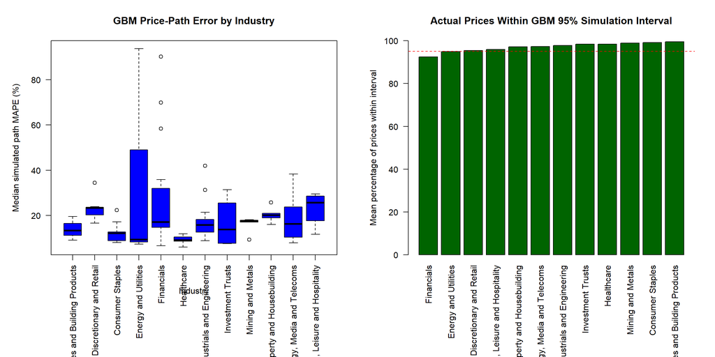

```r
# Price Path Error by Industry

par(mfrow = c(1, 2), mar = c(10, 5, 4, 2))

# Display both graphs side by side
par(
  mfrow = c(1, 2),
  mar = c(10, 5, 4, 2)
)

# Graph 1: Price Path Error by Industry
boxplot(
  Median_Path_MAPE ~ Industry,
  data = gbm_fit_stock_results,
  las = 2,
  col = "blue",
  ylab = "Median simulated path MAPE (%)",
  main = "GBM Price-Path Error by Industry",
  outline = TRUE
)

# Graph 2: Actual Price Coverage
coverage_data <- gbm_fit_industry_summary[
  order(gbm_fit_industry_summary$Mean_95_Percent_Coverage),
]

barplot(
  coverage_data$Mean_95_Percent_Coverage,
  names.arg = coverage_data$Industry,
  las = 2,
  col = "darkgreen",
  ylim = c(0, 100),
  ylab = "Mean percentage of prices within interval",
  main = "Actual Prices Within GBM 95% Simulation Interval"
)

# Reference line at 95% coverage
abline(h = 95, lty = 2, col = "red")
```

```r
# Reset layout for any subsequent plots
par(mfrow = c(1, 1))
```

**Median Path MAPE:** This measures the median percentage error between the simulated GBM price paths and the actual historical stock prices. Lower values indicate that the simulated paths tend to remain closer to the observed prices, suggesting a better fit to the historical data.

**Log Price RMSE:** This measures the root mean squared error between simulated and actual log stock prices. Lower values indicate smaller discrepancies between the simulated and observed prices, while higher values suggest that GBM struggles to represent the stock’s historical price movements accurately.

**95% Coverage:** This measures the percentage of actual stock prices that fall within the 95% simulation interval. Coverage close to 95% is consistent with the nominal interval coverage, whereas lower coverage may indicate that the model underestimates uncertainty. Higher coverage is not necessarily better, as wider intervals can capture more observations without providing more precise predictions.

### Conclusion across Industries

Overall, The results indicate that GBM can provide a reasonable approximation of historical price movements, but its effectiveness varies considerably between industries. Healthcare and Energy and Utilities produced the lowest median path MAPE values of 9.01% and 9.32%, respectively, whereas Travel, Leisure and Hospitality recorded the highest error at 25.62%. This suggests that GBM is more effective at reproducing price movements for some sectors than others.

Although mean 95% coverage was high across all industries, ranging from 92.43% to 99.47%, this does not necessarily indicate strong predictive accuracy, as wider confidence intervals can contain observed prices despite substantial differences between simulated and actual paths. Taken together, the findings suggest that GBM is a useful starting point for modelling underlying asset prices, but its assumptions should not be accepted universally. In the context of option pricing and real-options valuation, these limitations are important because an unsuitable price model may affect valuation reliability, particularly where extreme movements or complex price dynamics are significant. However, since this project focuses on historical price simulations rather than directly comparing option prices, further research would be needed to quantify the impact on valuations and assess whether alternative models provide better results.

# Further Directions

1. How to deal with dividends
2. Use both the close and open columns (as well as the high and low)
3. Analysis:
   1. Vary number of walks?
   2. Vary time period
   3. Change parameters based on rolling time periods rather than having one consistent parameter over the entire time
4. Jarque - Bera test for if log returns are normally distribution
5. Which tests to apply to every single stock
6. Maybe change the industries based on FTSE classification / a more concrete specification
7. Compare the performance of the entire FTSE index over the time period
8. create conclusion framework for industries - consider beta across industries and cyclical exposure

To discuss

1. All of above
2. what time period to take from the data (maybe one with low volatility)